# W271 Live Session 9: ARIMA and SARIMA

Jeffrey Yau, Devesh Tiwari

3/7/2017

# Main topics covered in Week 9

- Mixed Autoregressive Moving Average (ARMA) Models
  - Mathematical formulation and derivation of key properties
  - Comparing ARMA models and AR models using simulated series
  - Comparing ARMA models and AR models using an example
- An introduction to non-stationary time series model
- Random walk and integrated processes
- Autoregressive Integrated Moving Average (ARIMA) Models
  - Review the steps to build ARIMA time series model
  - Simulation
  - Modeling with simulated data using the Box-Jenkins approach
  - Estimation, model diagnostics, model identification, model selection, assumption testing, and statistical inference / forecasting, backtesting
- Seasonal ARIMA (SARIMA) Models
  - Mathematical formulation
  - An empirical example
- Putting everything together: ARIMA modeling

# Readings

**CM2009:** Paul S.P. Cowpertwait and Andrew V. Metcalfe. *Introductory Time Series with R*. Springer. 2009.

- Ch. 4.3 – 4.7, 6, 7.1 – 7.3

**SS2016:** Robert H. Shumway and David S. Stoffer. *Time Series Analysis and Applications.* EZ Edition with R Examples:

- 3.7 – 3.10, review 3.1 – 3.6

**HA:** Rob J Hyndman and George Athanasopoulos. Forecasting: Principles and Practice:

- Ch. 8.5 – 8.9

# Agenda for this week’s live session:

1. Recap (15 mins)
2. Review questions (15 mins)
3. Breakout Session 1: EDA (10 minutes breakout; 10 minutes discussion)
4. Group discussion: Non-seasonal modeling (15 minutes)
5. Breakout Session 2: Seasonal Modeling (time remaining)

# Recap and overview

1. Last week, we were introduced to autoregressive (AR), moving average (MA), and autoregressive moving average (ARMA) models. These models are only appriorate for time-series that are weakly stationary (stationary in the mean and the variance).
2. We often are confronted with time-series that is not stationary in the mean and variance. Luckily for us, we can transform these series in order to make them stationary!
3. Here is an incomplete list of how/why time-series might not be stationary in the mean:
   1. Data has a trend
   2. Data contains a unit-root (next week)
   3. Data contains seasonal elements
4. We can take care of these problems either by detrending the data or by differencing the data. Once the data are transformed into a weakly stationary series, we can model the resulting series with an ARMA model. We call these models ARIMA models if the data do not exhibit any seasonality. If the data are seasonal, then these models are called SARIMA models.
5. Remember, here are the steps to building an ARIMA model!
   1. Conduct and EDA to determine if you need to transform the data in order to make it stationary.
   2. Transform the data if needed.
   3. Estimate several Arima(p,d,q) models. Remember, you set the value of d in the first step! So really, you are trying to find the apprioriate values of p and q.
   4. Evaluate the residuals of models with the lowest AIC/BIC values and simpler models. Select the model where the residuals resemble white nose.
   5. If you still have some candidate models remaining, then conduct an out of sample test and select the model with the lowest forecasting error.
   6. Answer your question / generate forecasts!

# Breakout Session 1: Review Questions

1. Consider the pure Moving Average process below, where $\omega_t$ is a white noise process:
   $$x_{t} = \omega_{t} + \beta_1\omega_{t-1}$$

Under what circumstances is this process stationary in the mean?

1. Always
2. Never, this is not an AR(p) process.
3. When the absolute value of $\beta_{1}$ is less than 1.
4. When the absolute value of the roots of the characteristic polynomial is greater thane 1.
2. Consider a time series represented by the following equation:

$$(1 - \alpha_1 \textbf{B} - \alpha_2 \textbf{B}^2)(1 - \textbf{B})x_{t} = \omega_{t} (1 + \beta_1 \textbf{B})$$

1. Describe this time series using the ARIMA(p,d,q) notation.
2. Can you tell if this time series is stationary? If so, is it? If you cannot determine whether it is stationary, what additional information do you need?

# Breakout Session 2: EDA and data transformation

Remember that we can express a SARIMA model as: SARIMA(p,d,q)x(P,D,Q),m.

`r`r # Insert the function to *tidy up* the code when they are printed out library(knitr) opts_chunk$set(tidy.opts=list(width.cutoff=60),tidy=TRUE)

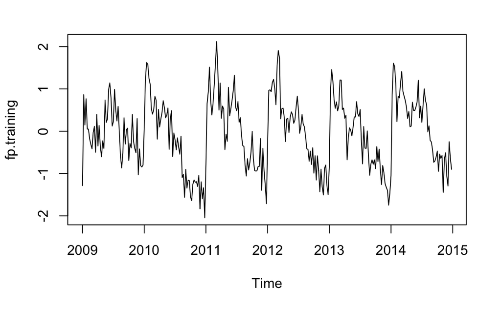

As we can see, this time-series is clearly not stationary in the mean! It is also pretty apparent that the time-series exhibits a lot of seasonality! Remember, at this stage we want to determine the values for d and D!

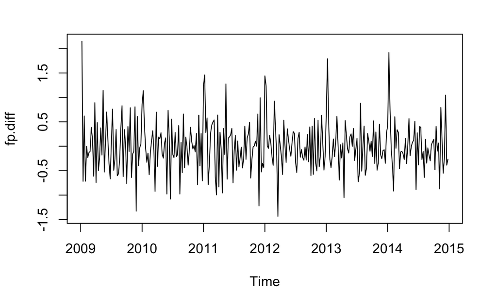

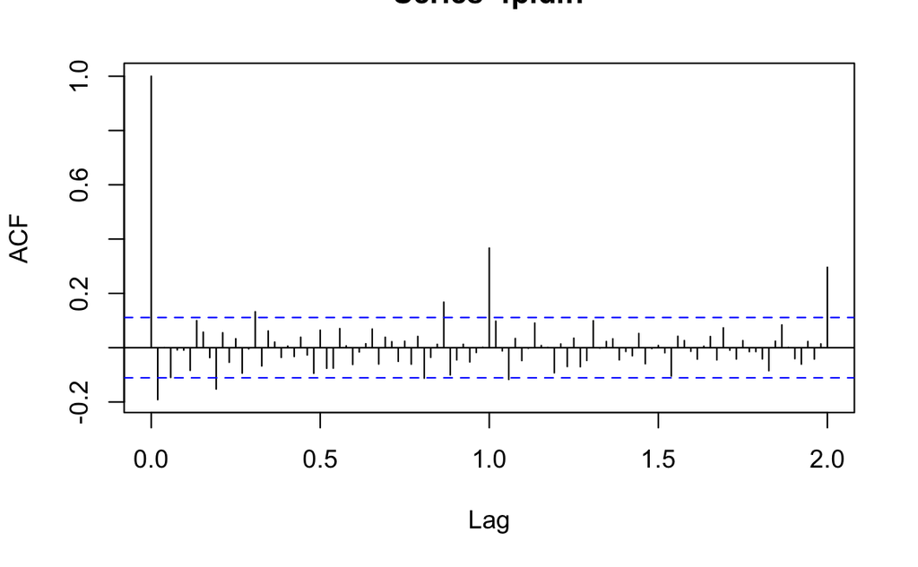

`r`r fp.diff <- diff(fp.training, lag = 1) plot(fp.diff) acf(fp.diff, lag.max = 104)

pacf(fp.diff, lag.max = 104)

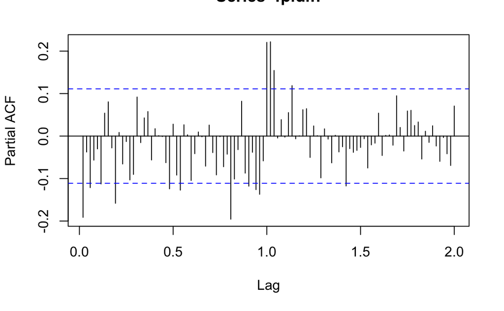

Moving on to the seasonal component…

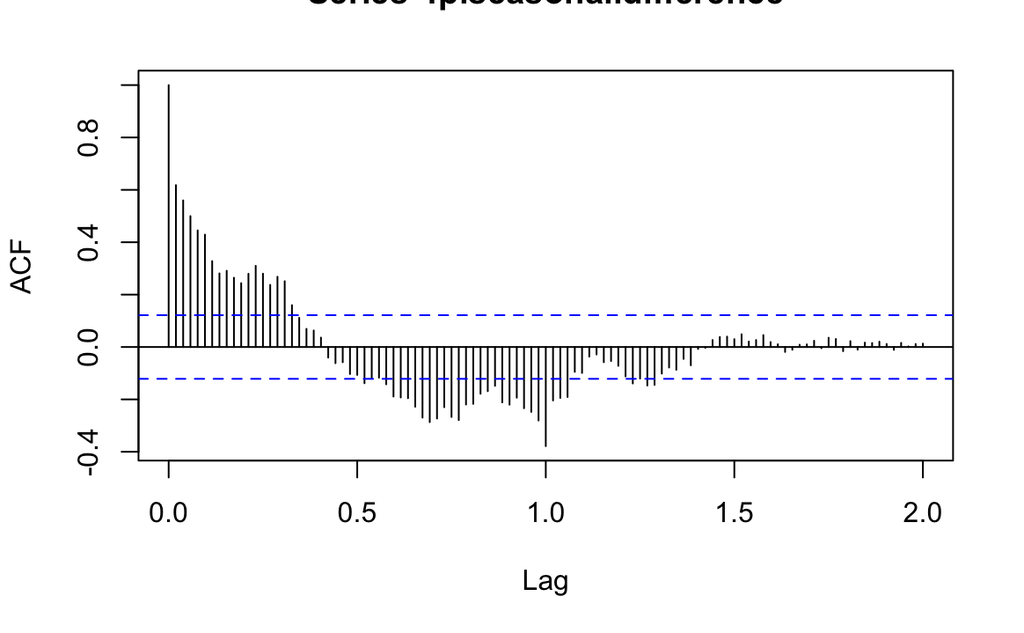

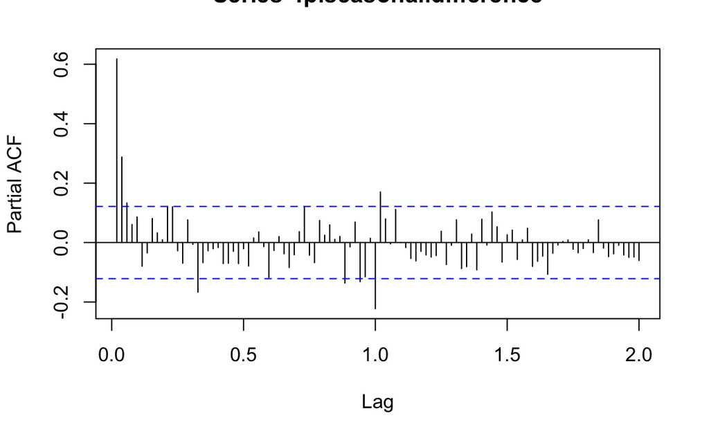

# Group discussion: Modeling the non-seasonal component

We have established that for our modeling purposes, d = 1 and D = 1. Now, we need to model the non-seasonal component of the raw series. In order to do that, we are going to use the Arima function in the forecast package.

`r`r hist(model.non.seas1$residuals)

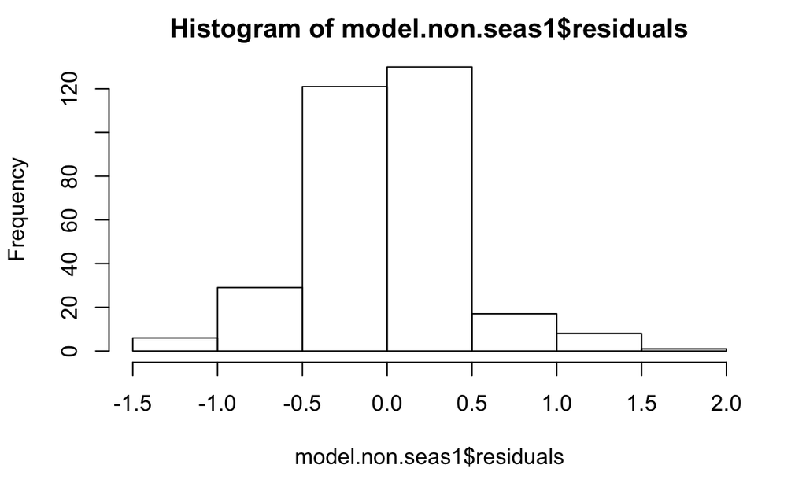

`r`r acf(model.non.seas1$residuals, lag.max = 104)

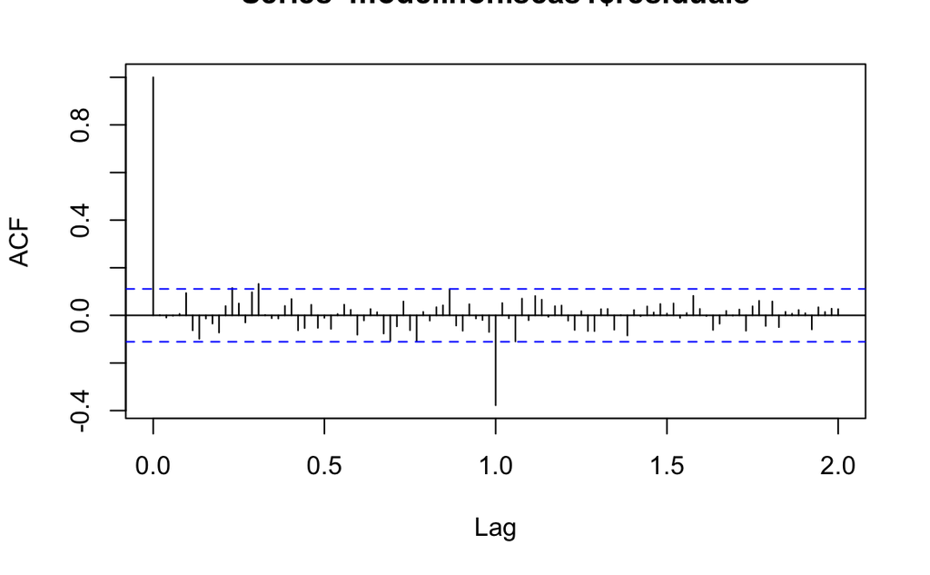

`r`r pacf(model.non.seas1$residuals, lag.max = 104)

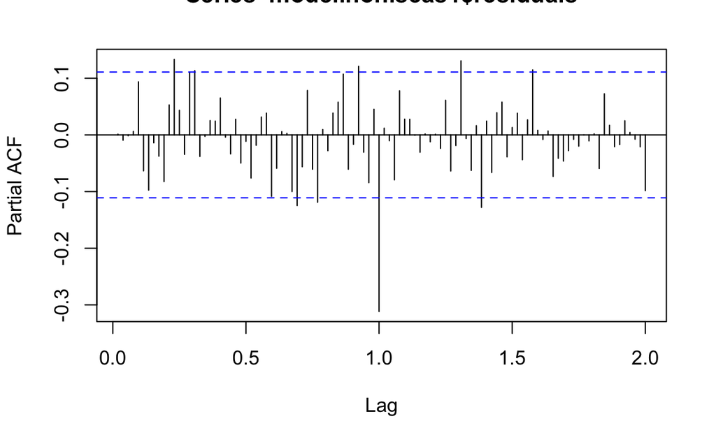

# Breakout Session: Modeling the seasonal component

In your group, try to find appropriate values for P and Q. Use the code from above if you wish or you can use your own. For now, set p,d,q to 1,1,0 respectively, but keep in mind that we might have to change our values for p and q after we add the seasonal component!

# Take home exercise

By now, you may have more than one candidate model. For each model:

```
1. Examine the residuals of your candidate models. Which ones produce well behaved residuals?

2. Conduct out of sample tests on the test data. Which model has the lowest forecasting error?
```